```python
import matplotlib.pyplot as plt
import pandas as pd
```

```python
df = pd.read_csv("Desktop/EmployeeSalaries/ds_salaries.csv")
```

**Reading the .csv file to import our data set.

```python
print(df.head())
```

```
   Unnamed: 0  work_year experience_level employment_type  \
0           0       2020               MI              FT
1           1       2020               SE              FT
2           2       2020               SE              FT
3           3       2020               MI              FT
4           4       2020               SE              FT

                    job_title  salary salary_currency  salary_in_usd  \
0              Data Scientist   70000             EUR          79833
1  Machine Learning Scientist  260000             USD         260000
2           Big Data Engineer   85000             GBP         109024
3        Product Data Analyst   20000             USD          20000
4   Machine Learning Engineer  150000             USD         150000

  employee_residence  remote_ratio company_location company_size
0                 DE             0               DE            L
1                 JP             0               JP            S
2                 GB            50               GB            M
3                 HN             0               HN            S
4                 US            50               US            L
```

**First look at the table. This gives us our column names and the first five rows of information.

```python
df.salary_in_usd.mean()
```

```
112297.86985172982
```

**Out of curiosity I wanted to see what the average salary was across the board with no regard for experience level or job title.

```python
df.employee_residence.value_counts()
```

```
employee_residence
US    332
GB     44
IN     30
CA     29
DE     25
FR     18
ES     15
GR     13
JP      7
PT      6
BR      6
PK      6
NL      5
PL      4
IT      4
RU      4
AE      3
AT      3
VN      3
TR      3
AU      3
RO      2
BE      2
SG      2
SI      2
DK      2
HU      2
NG      2
MX      2
BO      1
MY      1
TN      1
IE      1
DZ      1
AR      1
CZ      1
JE      1
LU      1
PR      1
RS      1
EE      1
CL      1
HK      1
KE      1
MD      1
CO      1
IR      1
CN      1
MT      1
UA      1
IQ      1
HN      1
BG      1
HR      1
PH      1
NZ      1
CH      1
Name: count, dtype: int64
```

**Checking to see where most of our information comes from. 332 entries hardly counts as concrete data to form any kind of true insights from, however this exercise is more about the process than the insights so it will work for our purposes.

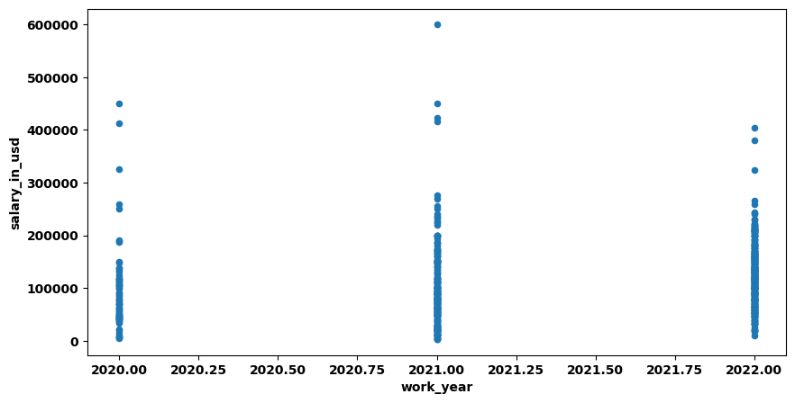

```python
df.plot.scatter(x='work_year', y='salary_in_usd', figsize=(10, 5))
```

**Checking the salary concentration globally first. Ultimately I didn't find the year metric to be very useful for how our data is laid out, so I don't continue using it for analysis.

```python
df_US = df[(df['employee_residence'] == 'US')]
```

**Limiting our scope to the US, which is both the largest pool of data and the most relevant for me, personally.

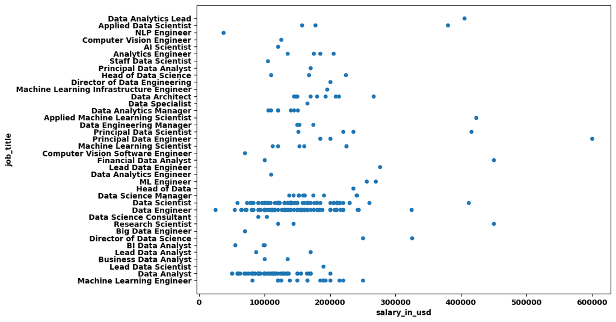

```python
df_US.plot.scatter(y='job_title', x='salary_in_usd', figsize=(10,7))
```

**That is a lot of job titles! I end up narrowing it down later, but this spread is really cool to look at, however a bit hard to follow for some job titles.

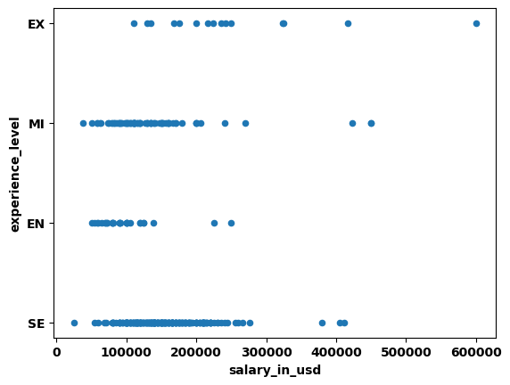

```python
df_US.plot.scatter(y='experience_level', x='salary_in_usd')
```

**Our first look at the ultimate goal of this analysis. You can see the distribution of salary falls pretty much exactly where you would expect. EN (entry level) concentrated to the lower end of the spectrum, MI (middle) a bit higher, SE (senior) a bit higher, and EX (executive) far above and beyond. I ended up excluding executive because it tended to negatively affect the numbers with that one person making ~$600,000. I could've just filtered that one out, but since the average worker isn't obtaining executive status it seemed more fair to focus on the first three tiers.

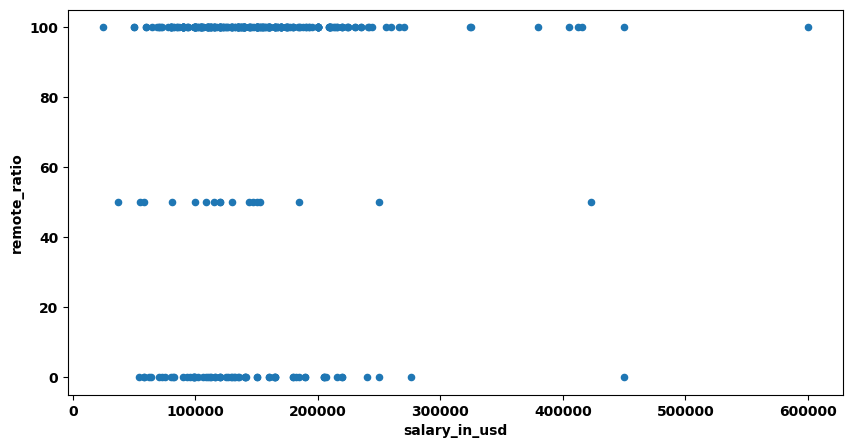

```python
df_US.plot.scatter(y='remote_ratio', x='salary_in_usd', figsize=(10,5))
```

```python
df_US_filtered = df_US[(df_US['salary_in_usd'] < 300000)]
```

**Filtered out people making more than 300,000 per year.

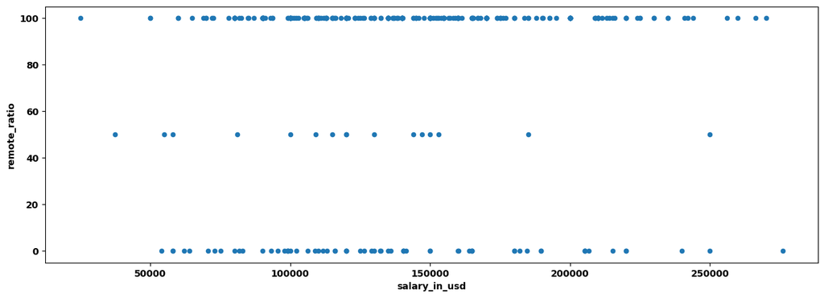

```python
df_US_filtered.plot.scatter(y='remote_ratio', x='salary_in_usd', figsize=(15,5))
```

**Remote vs. in-office. Results largely the same, the concentration of higher salaries is much greater on the remote side.

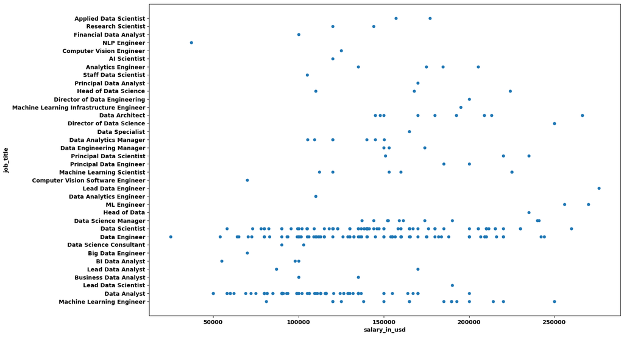

```python
df_US_filtered.plot.scatter(y='job_title', x='salary_in_usd', figsize=(15, 10))
```

**Visiting this idea again since the max salary has been limited to 300K. You can see how this data heavily focuses on data analysts, data engineers, and data scientists. I chose to narrow my focus even further to just data analysts since that is my career goal, after all!

```python
df_DA = df_US_filtered[(df_US_filtered['job_title'] == 'Data Analyst')]
```

**Executing that idea here by filtering out all careers except data analysis.

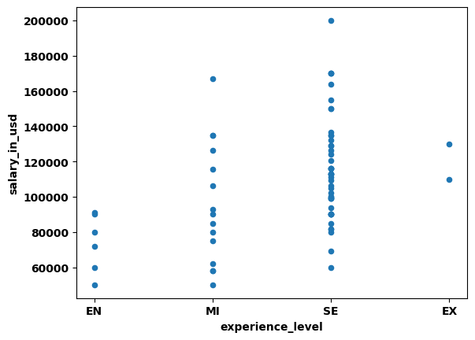

```python
df_DA.plot.scatter(x='experience_level', y='salary_in_usd')
```

**Breaking it down by experience level, the distribution is just beautiful! Perfectly in line what the expectation.

```python
avg_salary = df_DA.salary_in_usd.mean()
```

**Average US Data Analyst salary for curiosity's sake.

```python
print(avg_salary)
```

```
108069.5
```

```python
df_EN = df_DA[(df_DA['experience_level'] == 'EN')]
```

**Plotting the entry level salary distribution vs. the size of the company the person works for. The same is done for MI and SE below!

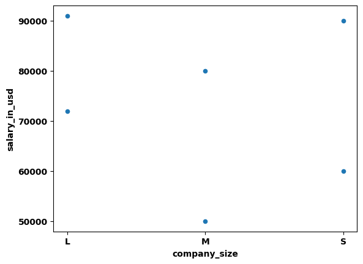

```python
df_EN.plot.scatter(x='company_size', y='salary_in_usd')
```

```python
df_MI = df_DA[(df_DA['experience_level'] == 'MI')]
```

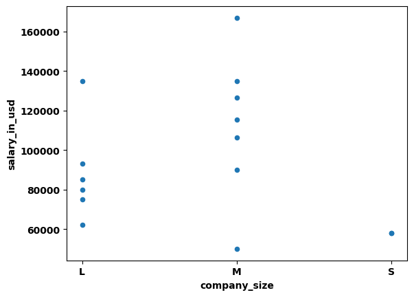

```python
df_MI.plot.scatter(x='company_size', y='salary_in_usd')
```

```python
df_SE = df_DA[(df_DA['experience_level'] == 'SE')]
```

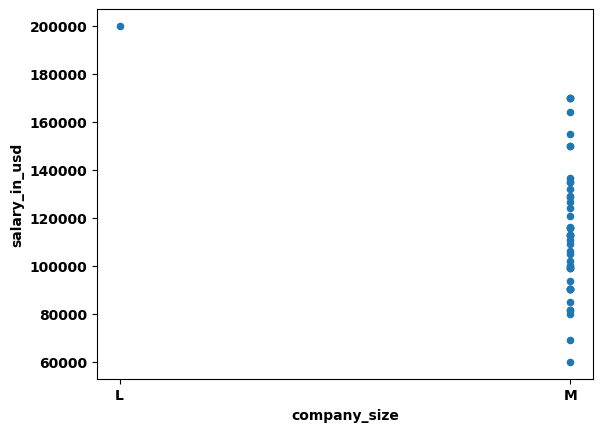

```python
df_SE.plot.scatter(x='company_size', y='salary_in_usd')
```

```python
df_EN.salary_in_usd.mean()
```

```
73833.33333333333
```

```python
df_MI.salary_in_usd.mean()
```

```
95750.66666666667
```

```python
df_SE.salary_in_usd.mean()
```

```
115863.93617021276
```

**And finally, our averages for entry level, mid level, and senior level data analysts in the US. Almost exactly 20K difference per level. Data is beautiful!